# Entrega 10.

Estadistica Computacional. Curso 2021-2022.

Carlota Valdivia Manzano.

19 de Mayo de 2022.

## Ejercicio 1

```r
nsim<-1000
set.seed(1)
x<-runif(nsim,-1,1)
y<-runif(nsim,-1,1)
suceso<-(x^2+y^2<=1)
```

Aproximación

```r
aprox<-mean(suceso)
```

Error de estimación

```r
sd(suceso)/sqrt(nsim)
```

```
## [1] 0.01331455
```

Gráfico de convergencia Aproximaciones para $n=1,...,nsim$

```r
estim<-cumsum(suceso)/(1:nsim)
```

Errores de estimación correspondientes

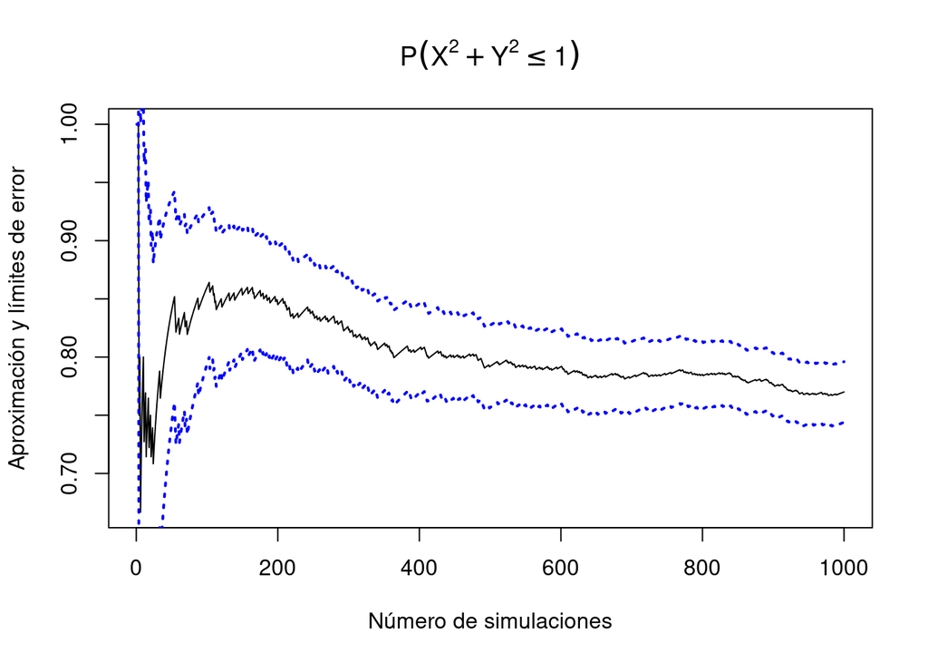

```r
estim.err<-sqrt(cumsum((suceso-estim)^2))/(1:nsim)

plot(1:nsim,estim,type='l',ylab="Aproximación y límites de error", xlab="Número de simulaciones", main=expression(P(X^2+Y^2<=1),ylim=c(0,1)))

z<-qnorm(0.025,lower.tail = FALSE)
lines(estim - z*estim.err, col="blue", lwd=2,lty=3)
lines(estim + z*estim.err, col="blue", lwd=2,lty=3)
```

Vemos cual sería el valor real y su diferencia

```r
value <- pi / 4.0
abs(value - aprox)
```

```
## [1] 0.01539816
```

Borramos memoria

```r
rm(list=ls(all=TRUE))
```

## Ejercicio 2

### Primera integral

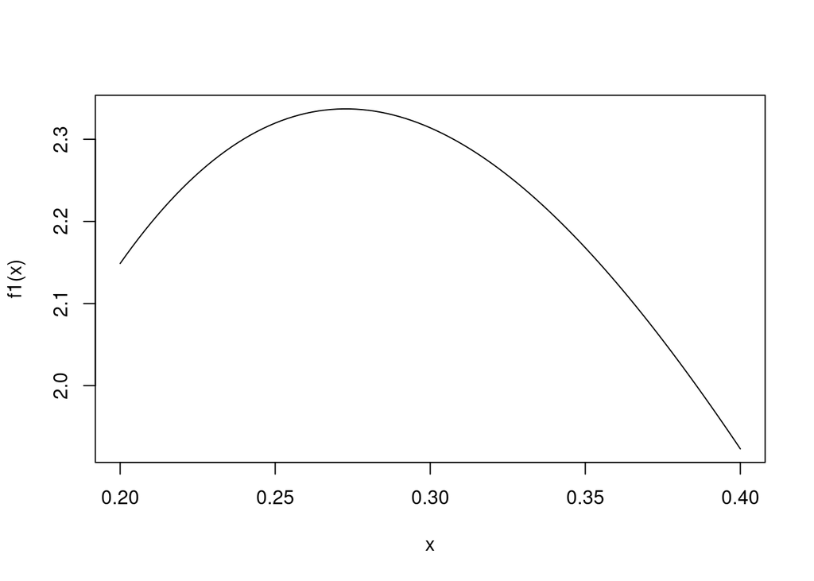

```r
f1<-function(x) dbeta(x,2.5,5)
curve(f1(x),0.2,0.4)
```

Aproximamos las dos integrales anteriores usando simulación Consideramos 1000 simulaciones

```r
nsim<-1000
```

Calculamos la aproximación

```r
set.seed(1)
x<-runif(nsim)
f1x<-sapply(x,f1)

mean(f1x)
```

```
## [1] 1.022192
```

Aproximaciones para $n=1,...,nsim$

```r
estim1<-cumsum(f1x)/(1:nsim)
```

Errores de estimación correspondientes

```r
estim1.err<-sqrt(cumsum((f1x-estim1)^2))/(1:nsim)
```

Construimos el gráfico que muestre la convergencia junto con los límites de error

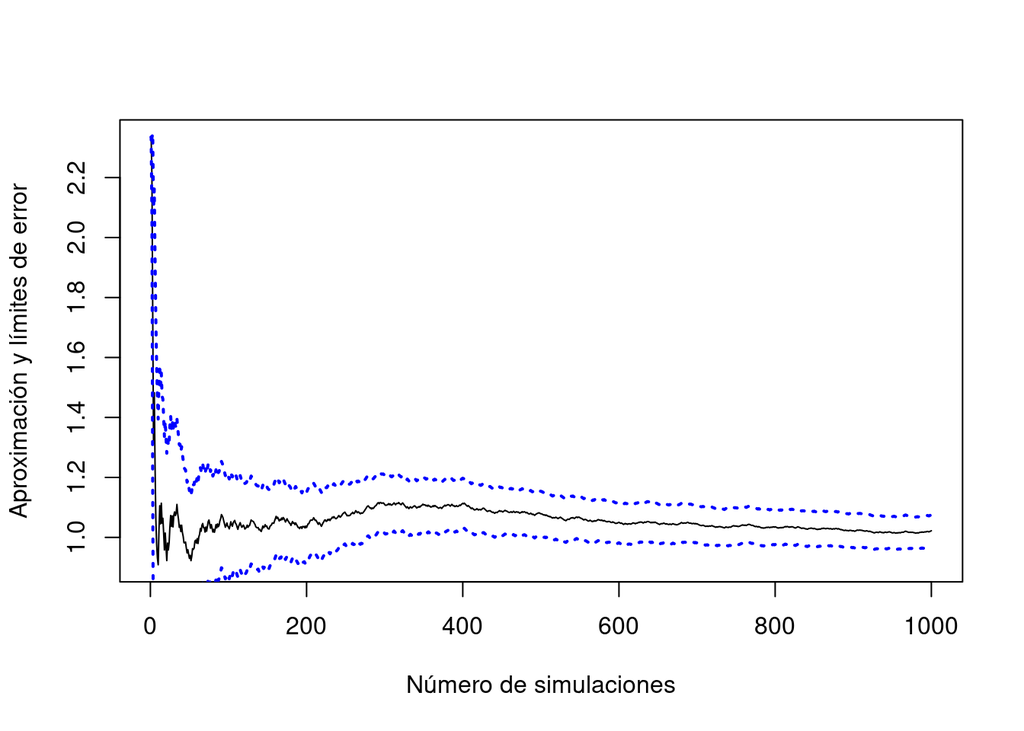

```r
plot(1:nsim,estim1,type='l',ylab='Aproximación y límites de error', xlab='Número de simulaciones')

z<-qnorm(0.025,lower.tail = FALSE)

lines(estim1 - z * estim1.err, col = "blue", lwd = 2, lty = 3)
lines(estim1 + z * estim1.err, col = "blue", lwd = 2, lty = 3)
```

### Segunda integral

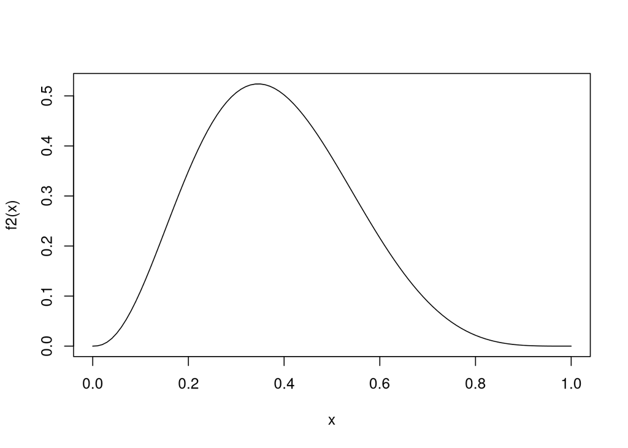

```r
f2<-function(x) sin(x)*exp(-x)*dbeta(x,2.5,5)
curve(f2(x),0,1)
```

Aproximamos las dos integrales anteriores usando simulación Consideramos 1000 simulaciones

```r
nsim<-1000
```

Definimos las integrales

```r
F2<-function(x) sin(x)*exp(-x)*dbeta(x,2.5,5) * (x>0 & x<1)
```

Calculamos la aproximación

```r
set.seed(1)
x<-runif(nsim)
f2x<-sapply(x,f2)

mean(f2x)
```

```
## [1] 0.2229711
```

Aproximaciones para $n=1,...,nsim$

```r
estim2<-cumsum(f2x)/(1:nsim)
```

Errores de estimación correspondientes

```r
estim2.err<-sqrt(cumsum((f1x-estim2)^2))/(1:nsim)
```

Construimos el gráfico que muestre la convergencia junto con los límites de error

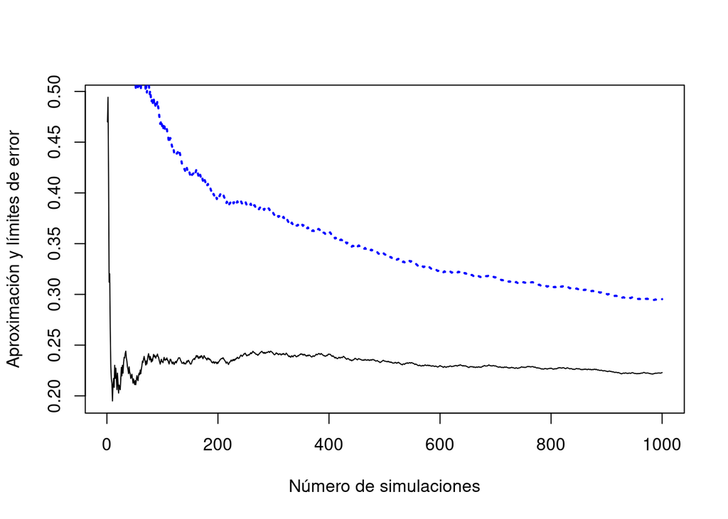

```r
plot(1:nsim,estim2,type='l',ylab='Aproximación y límites de error', xlab='Número de simulaciones')

z<-qnorm(0.025,lower.tail = FALSE)

lines(estim2 - z * estim2.err, col = "blue", lwd = 2, lty = 3)
lines(estim2 + z * estim2.err, col = "blue", lwd = 2, lty = 3)
```

Comparamos las aproximaciones obtenidas con las aproximaciones numericas que calcula la funcion integrate Primera integral

```r
f1<-function(x) dbeta(x,2.5,5)
integrate(f1,0.2,0.4)
```

```
## 0.4441656 with absolute error < 4.9e-15
```

También podemos evaluarla con la función pbeta()

```r
pbeta(0.4,2.5,5)-pbeta(0.2,2.5,5)
```

```
## [1] 0.4441656
```

Segunda integral

```r
f2<-function(x) sin(x)*exp(-x)*dbeta(x,2.5,5)
integrate(f2,-Inf,Inf)
```

```
## 0.2172255 with absolute error < 7.9e-05
```

Borramos memoria

```r
rm(list=ls(all=TRUE))
```

## Ejercicio 4

Parámetros de la lognormal (X)

```r
mu<-3.5
sig<-1.1
```

Calculamos E[X] y V(X)

```r
EX<-exp(mu+sig^2/2)
EX
```

```
## [1] 60.64274
```

```r
VX<-EX^2*(exp(sig^2)-1)
VX
```

```
## [1] 8655.04
```

Parámetro de la Poisson (N)

```r
lam<-17 #' coincide con E[N] y V(N)
```

Media de la Poisson compuesta

```r
ES<-lam*EX
ES
```

```
## [1] 1030.927
```

Varianza de la Poisson compuesta

```r
VS<-lam*VX + lam*EX^2
VS
```

```
## [1] 209653.9
```

Asignamos el número de simulaciones

```r
nsim<-5000
```

Simulamos ahora nsim valores de S_N:

```r
S <- double(nsim) #' para almacenar los valores simulados
set.seed(1)
for (i in 1:nsim) {
    n <- rpois(1,lam)
    if (n>0) S[i] <- sum(rlnorm(n,mu,sig))
}
```

S contiene los valores simulados de S_N Un histograma de S nos da una aproximación de la distribución Superponemos la densidad suavizada que calcula density()

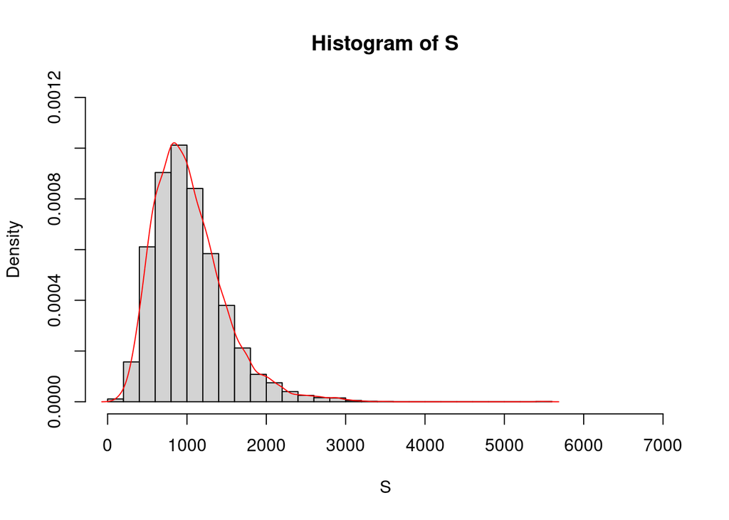

```r
hist(S,xlim=c(0,7000),breaks=20,prob=TRUE, ylim=c(0,1.2e-3))
lines(density(S),col="red")
```

Calculamos la media yla varianza de los nsim valores simulados

```r
mean(S)
```

```
## [1] 1028.819
```

```r
var(S)
```

```
## [1] 206025.3
```

Vemos que son muy parecido a E_S y V_S Aproximamos el VaR

```r
quantile(S, 0.995)
```

```
##    99.5%
## 2752.155
```

Aproximación por una Normal con media ES y varianza VS

```r
qnorm(0.995, mean=ES, sd=sqrt(VS))
```

```
## [1] 2210.347
```

Borramos memoria

```r
rm(list=ls(all=TRUE))
```